# Market Basket Analysis

Uche Kalu

4/8/2022

## Market Basket Analysis

Market Basket Analysis is also called **Association Rules**.

It is used to uncover links between items by large retailers. It works by searching for combinations of items that happen in transactions together

It uses such info to recognize customer purchasing patterns, to identify who customers are, to understand why you buy certain items and to know which products are purchased jointly so as to know which products to promote

Using Market Basket Analysis, we want to find out which consumer items from this hypothetical business dataset are bought together by customers

```r
mydata <- read.csv("Cosmetics.csv", header = T, colClasses = "factor")
```

#### **Lets access our business data**

```r
str(mydata)
```

```
## 'data.frame':    1000 obs. of  14 variables:
##  $ Bag            : Factor w/ 2 levels "No","Yes": 1 1 1 1 1 1 1 1 1 2 ...
##  $ Blush          : Factor w/ 2 levels "No","Yes": 2 1 2 1 2 1 2 1 1 2 ...
##  $ Nail.Polish    : Factor w/ 2 levels "No","Yes": 2 2 1 2 1 1 2 2 1 2 ...
##  $ Brushes        : Factor w/ 2 levels "No","Yes": 2 1 1 2 1 1 2 2 1 2 ...
##  $ Concealer      : Factor w/ 2 levels "No","Yes": 2 2 2 2 2 2 2 1 2 1 ...
##  $ Eyebrow.Pencils: Factor w/ 2 levels "No","Yes": 1 1 2 1 1 1 1 1 1 1 ...
##  $ Bronzer        : Factor w/ 2 levels "No","Yes": 2 2 2 2 2 1 2 2 1 1 ...
##  $ Lip.liner      : Factor w/ 2 levels "No","Yes": 2 2 2 1 2 1 2 1 1 1 ...
##  $ Mascara        : Factor w/ 2 levels "No","Yes": 2 1 2 1 2 1 2 2 1 2 ...
##  $ Eye.shadow     : Factor w/ 2 levels "No","Yes": 1 1 2 1 2 1 2 2 1 2 ...
##  $ Foundation     : Factor w/ 2 levels "No","Yes": 1 2 2 2 1 1 2 1 2 1 ...
##  $ Lip.Gloss      : Factor w/ 2 levels "No","Yes": 1 2 2 1 2 1 2 2 1 1 ...
##  $ Lipstick       : Factor w/ 2 levels "No","Yes": 1 1 2 1 2 1 1 1 2 1 ...
##  $ Eyeliner       : Factor w/ 2 levels "No","Yes": 2 1 1 2 1 2 1 1 1 1 ...
```

```r
summary(mydata)
```

```
##   Bag      Blush     Nail.Polish Brushes   Concealer Eyebrow.Pencils Bronzer
##  No :946   No :637   No :720     No :851   No :558   No :958         No :721
##  Yes: 54   Yes:363   Yes:280     Yes:149   Yes:442   Yes: 42         Yes:279
##  Lip.liner Mascara   Eye.shadow Foundation Lip.Gloss Lipstick  Eyeliner
##  No :766   No :643   No :619    No :464    No :510   No :678   No :543
##  Yes:234   Yes:357   Yes:381    Yes:536    Yes:490   Yes:322   Yes:457
```

#### This is the function used to create Market Basket Analysis

```r
yrdata <- apriori(mydata)
```

*The number of rules per item is displayed - 3 rules with 1 item, 85 rules in 2 items, 10739 rules with 5 items. also displays total number of rules- 68880 rules (which is to much)*

```r
summary(yrdata)
```

```
## set of 68880 rules
##
## rule length distribution (lhs + rhs):sizes
##     1     2     3     4     5     6     7     8     9    10
##     3    85   942  4350 10739 17062 18066 11996  4665   972
##
##    Min. 1st Qu.  Median    Mean 3rd Qu.    Max.
##   1.000   6.000   7.000   6.542   8.000  10.000
##
## summary of quality measures:
##     support         confidence        coverage           lift
##  Min.   :0.1000   Min.   :0.8000   Min.   :0.1000   Min.   :0.8781
##  1st Qu.:0.1150   1st Qu.:0.8667   1st Qu.:0.1250   1st Qu.:1.0389
##  Median :0.1370   Median :0.9453   Median :0.1490   Median :1.1565
##  Mean   :0.1583   Mean   :0.9259   Mean   :0.1718   Mean   :1.2019
##  3rd Qu.:0.1770   3rd Qu.:0.9821   3rd Qu.:0.1930   3rd Qu.:1.2438
##  Max.   :0.9580   Max.   :1.0000   Max.   :1.0000   Max.   :3.5714
##      count
##  Min.   :100.0
##  1st Qu.:115.0
##  Median :137.0
##  Mean   :158.3
##  3rd Qu.:177.0
##  Max.   :958.0
##
## mining info:
##    data ntransactions support confidence                   call
##  mydata          1000     0.1        0.8 apriori(data = mydata)
```

*Here we display d rules of all columns which are now values in lhs column(left hand side) which is ‘IF’ and rhs column(right hand side) which is ‘Then’ but they are all = NO (i.e which items was not bought - If Nail.Polish was not bought in lhs, Then Brushes was not bought in rhs). Since we want to see which item was bought, dis rule is not helpful.*

```r
inspect(myrules)
```

```
##      lhs                                   rhs                  support
## [1]  {Nail.Polish=No}                   => {Brushes=No}         0.720
## [2]  {Brushes=No}                       => {Nail.Polish=No}     0.720
## [3]  {Lip.liner=No}                     => {Bag=No}             0.732
## [4]  {Lip.liner=No}                     => {Eyebrow.Pencils=No} 0.734
## [5]  {Brushes=No}                       => {Bag=No}             0.817
## [6]  {Bag=No}                           => {Brushes=No}         0.817
## [7]  {Brushes=No}                       => {Eyebrow.Pencils=No} 0.820
## [8]  {Eyebrow.Pencils=No}               => {Brushes=No}         0.820
## [9]  {Bag=No}                           => {Eyebrow.Pencils=No} 0.909
## [10] {Eyebrow.Pencils=No}               => {Bag=No}             0.909
## [11] {Bag=No, Lip.liner=No}             => {Eyebrow.Pencils=No} 0.703
## [12] {Eyebrow.Pencils=No, Lip.liner=No} => {Bag=No}             0.703
## [13] {Bag=No, Brushes=No}               => {Eyebrow.Pencils=No} 0.789
## [14] {Brushes=No, Eyebrow.Pencils=No}   => {Bag=No}             0.789
```

[output cut: 17 more lines]

#### **Finding interesting rules- 1 (i.e rules that will display Yes in the lhs and rhs columns)**

*We see that Foundation column has highest values of Yes among all columns(as such it is d most popular item bought) and Eyebrow.Pencils has highest value for NO*

```r
summary(mydata)
```

```
##   Bag      Blush     Nail.Polish Brushes   Concealer Eyebrow.Pencils Bronzer
##  No :946   No :637   No :720     No :851   No :558   No :958         No :721
##  Yes: 54   Yes:363   Yes:280     Yes:149   Yes:442   Yes: 42         Yes:279
##  Lip.liner Mascara   Eye.shadow Foundation Lip.Gloss Lipstick  Eyeliner
##  No :766   No :643   No :619    No :464    No :510   No :678   No :543
##  Yes:234   Yes:357   Yes:381    Yes:536    Yes:490   Yes:322   Yes:457
```

```r
myrules <- apriori(mydata, parameter = list(minlen = 2, maxlen = 3,
                                           conf = 0.7),
                   appearance = list(rhs = c("Foundation=Yes"),
                                     default = "lhs"))
```

```
## Apriori
##
## Parameter specification:
##  confidence minval smax arem  aval originalSupport maxtime support minlen
##         0.7    0.1    1 none FALSE            TRUE       5     0.1      2
##  maxlen target  ext
##       3  rules TRUE
##
## Algorithmic control:
##  filter tree heap memopt load sort verbose
##     0.1 TRUE TRUE  FALSE TRUE    2    TRUE
##
## Absolute minimum support count: 100
##
## set item appearances ...[1 item(s)] done [0.00s].
## set transactions ...[28 item(s), 1000 transaction(s)] done [0.00s].
## sorting and recoding items ... [26 item(s)] done [0.00s].
## creating transaction tree ... done [0.00s].
## checking subsets of size 1 2 3 done [0.01s].
## writing ... [16 rule(s)] done [0.00s].
## creating S4 object  ... done [0.00s].
```

*This displays rules with Yes values(ie If Lip.Gloss was bought in lhs, Then Foundation was also bought in rhs) in lhs and rhs columns but there are still rules with No values displayed in lhs so dis rules is not of interest to us*

```r
inspect(myrules)
```

```
##      lhs                                    rhs              support confidence
## [1]  {Lip.Gloss=Yes}                     => {Foundation=Yes} 0.356   0.7265306
## [2]  {Lip.Gloss=Yes, Lipstick=Yes}       => {Foundation=Yes} 0.116   0.7341772
## [3]  {Mascara=Yes, Lip.Gloss=Yes}        => {Foundation=Yes} 0.130   0.7182320
## [4]  {Eye.shadow=Yes, Lip.Gloss=Yes}     => {Foundation=Yes} 0.146   0.7263682
## [5]  {Lip.Gloss=Yes, Eyeliner=No}        => {Foundation=Yes} 0.200   0.7604563
## [6]  {Concealer=No, Lip.Gloss=Yes}       => {Foundation=Yes} 0.215   0.7904412
## [7]  {Eye.shadow=No, Lip.Gloss=Yes}      => {Foundation=Yes} 0.210   0.7266436
## [8]  {Blush=No, Lip.Gloss=Yes}           => {Foundation=Yes} 0.237   0.7596154
## [9]  {Mascara=No, Lip.Gloss=Yes}         => {Foundation=Yes} 0.226   0.7313916
## [10] {Lip.Gloss=Yes, Lipstick=No}        => {Foundation=Yes} 0.240   0.7228916
## [11] {Nail.Polish=No, Lip.Gloss=Yes}     => {Foundation=Yes} 0.267   0.7500000
## [12] {Bronzer=No, Lip.Gloss=Yes}         => {Foundation=Yes} 0.295   0.8452722
## [13] {Lip.liner=No, Lip.Gloss=Yes}       => {Foundation=Yes} 0.310   0.8288770
## [14] {Brushes=No, Lip.Gloss=Yes}         => {Foundation=Yes} 0.313   0.7417062
```

[output cut: 19 more lines]

## Graphs and Charts

```r
library(arulesViz)
```

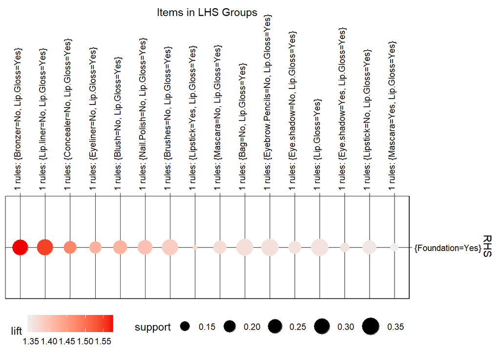

```r
plot(myrules, method = "grouped")
```

[output not shown]

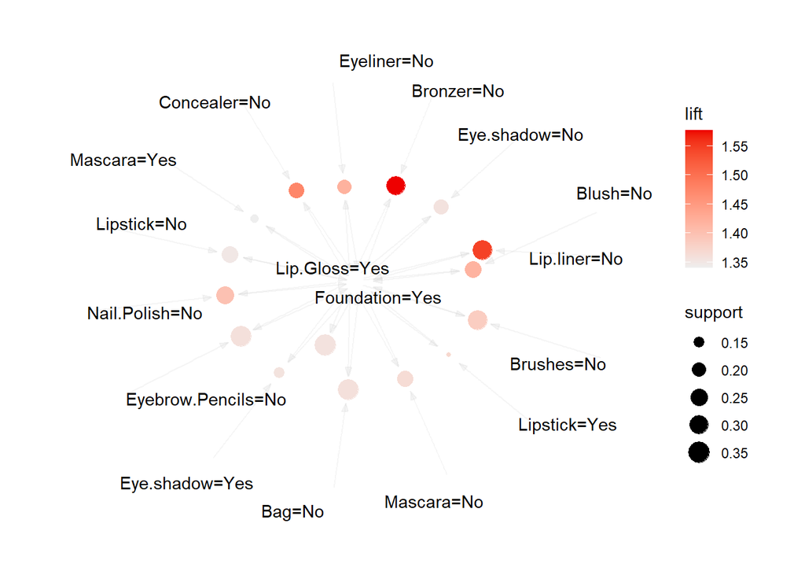

```r
plot(myrules, method = "graph", control = list(type = "items"))
```

#### **Finding interesting rules - 2 (ie displaying only rules with Yes values in lhs and rhs columns)**

*Lets list all the rules in lhs and rhs columns that have value- Yes*

```r
myrules <- apriori(mydata, parameter = list(minlen = 2, maxlen = 3,
                                           conf = 0.5),
                   appearance = list(rhs = c("Foundation=Yes"), lhs = c("Bag=Yes", "Blush=Yes", "Nail.Polish=Yes", "Brushes=Yes", "Concealer=Yes", "Eyebrow.Pencils=Yes", "Bronzer=Yes", "Lip.liner=Yes", "Mascara=Yes", "Eye.shadow=Yes", "Lip.Gloss=Yes", "Lipstick=Yes", "Eyeliner=Yes"), default = "none"))
```

[output not shown]

*This displays only rules with Yes values in lhs and rhs columns (ie If people bought Lipstick Then they also bought Foundation etc)*

```r
inspect(myrules)
```

```
##      lhs                                rhs              support confidence
## [1]  {Lipstick=Yes}                  => {Foundation=Yes} 0.167   0.519
## [2]  {Nail.Polish=Yes}               => {Foundation=Yes} 0.143   0.511
## [3]  {Blush=Yes}                     => {Foundation=Yes} 0.192   0.529
## [4]  {Mascara=Yes}                   => {Foundation=Yes} 0.192   0.538
## [5]  {Eye.shadow=Yes}                => {Foundation=Yes} 0.211   0.554
## [6]  {Eyeliner=Yes}                  => {Foundation=Yes} 0.238   0.521
## [7]  {Lip.Gloss=Yes}                 => {Foundation=Yes} 0.356   0.727
## [8]  {Concealer=Yes}                 => {Foundation=Yes} 0.231   0.523
## [9]  {Lip.Gloss=Yes, Lipstick=Yes}   => {Foundation=Yes} 0.116   0.734
## [10] {Blush=Yes, Mascara=Yes}        => {Foundation=Yes} 0.101   0.549
## [11] {Blush=Yes, Eye.shadow=Yes}     => {Foundation=Yes} 0.100   0.549
## [12] {Blush=Yes, Lip.Gloss=Yes}      => {Foundation=Yes} 0.119   0.669
## [13] {Blush=Yes, Concealer=Yes}      => {Foundation=Yes} 0.115   0.523
## [14] {Mascara=Yes, Eye.shadow=Yes}   => {Foundation=Yes} 0.166   0.517
```

[output cut: 29 more lines]

#### **Finding and Displaying Redundant rules**

```r
which(myredun)
```

```
##                 {Foundation=Yes,Lipstick=Yes}
##                                             1
##              {Nail.Polish=Yes,Foundation=Yes}
##                                             2
##                    {Blush=Yes,Foundation=Yes}
##                                             3
##                  {Mascara=Yes,Foundation=Yes}
##                                             4
##               {Eye.shadow=Yes,Foundation=Yes}
##                                             5
##                 {Foundation=Yes,Eyeliner=Yes}
##                                             6
##                {Foundation=Yes,Lip.Gloss=Yes}
##                                             7
##                {Concealer=Yes,Foundation=Yes}
##                                             8
##   {Foundation=Yes,Lip.Gloss=Yes,Lipstick=Yes}
##                                             9
##        {Blush=Yes,Mascara=Yes,Foundation=Yes}
##                                            10
##     {Blush=Yes,Eye.shadow=Yes,Foundation=Yes}
##                                            11
##      {Blush=Yes,Foundation=Yes,Lip.Gloss=Yes}
##                                            12
##      {Blush=Yes,Concealer=Yes,Foundation=Yes}
##                                            13
##   {Mascara=Yes,Eye.shadow=Yes,Foundation=Yes}
##                                            14
##    {Mascara=Yes,Foundation=Yes,Lip.Gloss=Yes}
##                                            15
##    {Concealer=Yes,Mascara=Yes,Foundation=Yes}
##                                            16
## {Eye.shadow=Yes,Foundation=Yes,Lip.Gloss=Yes}
##                                            17
## {Concealer=Yes,Eye.shadow=Yes,Foundation=Yes}
##                                            18
##   {Foundation=Yes,Lip.Gloss=Yes,Eyeliner=Yes}
##                                            19
##   {Concealer=Yes,Foundation=Yes,Eyeliner=Yes}
##                                            20
##  {Concealer=Yes,Foundation=Yes,Lip.Gloss=Yes}
##                                            21
```

#### **Removing Redundant rules**

```r
yrrules <- myrules[!myredun]  # removes d redundant rules

yrrules <- sort(yrrules, by = "lift")
```

```r
inspect(yrrules)
```

[output not shown]